# Utah Lake CHL-Method x Parameter Review

Analysis

T.Hooker

02 July, 2019

**Project Root Path** :: "L:MANAGEMENT & QA.Projects_CHLA-CHLA_R"

```r
#options(table_counter=FALSE)
tidy_package <- c("plyr", "dplyr", "tidyr", "magrittr", "htmlTable")
# suppressPackageStartupMessages(library("tidy"))
if(!"tidyr" %in% (.packages())) {invisible(lapply(tidy_package, function(x) suppressMessages(library(x, character.only=T, quietly = T, warn.conflicts = F))))}
##
graph_package <- c("ggplot2", "scales")
 if(!"ggplot2" %in% (.packages())) {invisible(lapply(graph_package, library, character.only=T, quietly = T, warn.conflicts = F))}
##
options(scipen = 999, digits = 4, stringsAsFactors = FALSE, keep.source = TRUE)
##
#startwork.date <- format(Sys.Date(), "%y%m%d")
knitr::opts_chunk$set(cache=TRUE)
```

### Notes

Compare Parameter x Method combinations for CHL over time, for UTLK data

### 1.0 Data Import

Link from SDaly ::

> “P:FilesLake1.Utah Lake Project Management Files\2_Data Management & Monitoring\03_FinalDataChemistry_DB\ul_data_wqp_raw_2019-05-06.csv”

```r
file_UTLK <- choose.files(caption="Select _working_ DATA file [*.xlsx]", multi = FALSE)
UTLK_0 <- read.csv(file_UTLK,
                   row.names=FALSE, check.names = TRUE,
                   stringsAsFactors = FALSE)
```

```
Error in read.table(file = file, header = header, sep = sep, quote = quote,  :
  invalid 'row.names' specification
```

- Selection of the R-data set gives a list of DFs
- **File** :: ul_data_wqp_raw_2019-05-06.csv
- **Path** :: P:/WQ/WPS/TMDL Files/Utah Lake/Phase 1.Utah Lake Project Management Files/2_Data Management & Monitoring/03_FinalData/Water Chemistry_DB
- **File Date** :: 05/06/2019

### 2.0 Review Data Structure

```r
data.file <- UTLK_0
#
Data.Vars <- data.frame()
for (i in 1:length(names(data.file))) {
  class_i <- class(data.file[,i])
  name_i <- names(data.file[i])
  num.NAs <- sum(is.na(data.file[,i]))
  count_levels <- as.numeric(length(unique((data.file[,i]))))
  num.blanks <- length(data.file[as.character(data.file[,i]) == "",c(i)]) # fixed for dates
  num.Obs <- nrow(data.file)-num.blanks
Data.Vars <- rbind(Data.Vars, data.frame(i, name_i, class_i, num.NAs, count_levels, num.blanks, num.Obs)) }
#
##
htmltools::knit_print.html(htmlTable::htmlTable(Data.Vars, caption ="Structure of UTLK-CHL file from WQP", align = c("clc|c"), css.cell = rbind(rep("padding-left: 0.7em; padding-right: 0.7em;font-size: 0.8em;", times=ncol(Data.Vars)), matrix("padding-left: 0.7em; padding-right: 0.7em; font-size: 0.8em;",ncol=ncol(Data.Vars), nrow=nrow(Data.Vars))), rnames = FALSE, header = c("Field No.", "Field Name", "Class","NAs", "Levels", "Blanks", "Obs")))
```

| Structure of UTLK-CHL file from WQP Field No. | Structure of UTLK-CHL file from WQP Field Name | Structure of UTLK-CHL file from WQP Class | Structure of UTLK-CHL file from WQP NAs | Structure of UTLK-CHL file from WQP Levels | Structure of UTLK-CHL file from WQP Blanks | Structure of UTLK-CHL file from WQP Obs |
| --- | --- | --- | --- | --- | --- | --- |
| 1 | OrganizationIdentifier | character | 0 | 1 | 0 | 48071 |
| 2 | OrganizationFormalName | character | 0 | 1 | 0 | 48071 |
| 3 | MonitoringLocationIdentifier | character | 0 | 23 | 0 | 48071 |
| 4 | ActivityIdentifier | character | 0 | 3145 | 0 | 48071 |
| 5 | ResultIdentifier | character | 0 | 48071 | 0 | 48071 |
| 6 | CharacteristicName | character | 0 | 100 | 0 | 48071 |
| 7 | ProviderName | character | 0 | 1 | 0 | 48071 |
| 8 | ActivityStartDate | character | 0 | 150 | 0 | 48071 |
| 9 | ActivityStartTime.Time | character | 5740 | 750 | 5740 | 42331 |
| 10 | ActivityStartTime.TimeZoneCode | character | 5740 | 3 | 5740 | 42331 |
| 11 | DataLoggerLine | character | 28709 | 39 | 28709 | 19362 |
| 12 | ResultDetectionConditionText | character | 42715 | 4 | 42715 | 5356 |
| 13 | MethodSpecificationName | character | 42577 | 7 | 42577 | 5494 |
| 14 | ResultSampleFractionText | character | 22668 | 4 | 22668 | 25403 |
| 15 | ResultMeasureValue | numeric | 5356 | 8670 | 5356 | 42715 |
| 16 | ResultMeasure.MeasureUnitCode | character | 0 | 13 | 0 | 48071 |
| 17 | MeasureQualifierCode | character | 44308 | 6 | 44308 | 3763 |
| 18 | ResultStatusIdentifier | character | 0 | 3 | 0 | 48071 |
| 19 | StatisticalBaseCode | logical | 48071 | 1 | 48071 | 0 |
| 20 | ResultValueTypeName | character | 0 | 2 | 0 | 48071 |
| 21 | ResultWeightBasisText | logical | 48071 | 1 | 48071 | 0 |
| 22 | ResultTimeBasisText | character | 47990 | 2 | 47990 | 81 |
| 23 | ResultTemperatureBasisText | character | 48001 | 2 | 48001 | 70 |
| 24 | ResultParticleSizeBasisText | logical | 48071 | 1 | 48071 | 0 |
| 25 | PrecisionValue | logical | 48071 | 1 | 48071 | 0 |
| 26 | DataQuality.BiasValue | logical | 48071 | 1 | 48071 | 0 |
| 27 | ConfidenceIntervalValue | logical | 48071 | 1 | 48071 | 0 |
| 28 | UpperConfidenceLimitValue | logical | 48071 | 1 | 48071 | 0 |
| 29 | LowerConfidenceLimitValue | logical | 48071 | 1 | 48071 | 0 |
| 30 | ResultCommentText | character | 24691 | 4019 | 24691 | 23380 |

[output cut: 159 more lines]

- `CharacteristicName`

```r
UTLK_0 %>% distinct(CharacteristicName) %>% nrow()
```

```
[1] 100
```

```r
UTLK_0 %>% distinct(CharacteristicName) %>% arrange(CharacteristicName)
```

| CharacteristicName |
| --- |
| .alpha.-Endosulfan |
| .alpha.-Hexachlorocyclohexane |
| .beta.-Endosulfan |
| .beta.-Hexachlorocyclohexane |
| .delta.-Hexachlorocyclohexane |
| 2,4-D |
| 2,4,5-T |
| Aldrin |
| Alkalinity, total |
| Aluminum |

[output cut: 90 more lines]

```r
# %>% htmlTable::htmlTable(., css.cell = rbind(rep("padding-left: 0.8em; padding-right: 0.8em;font-size: 0.75em;", times=ncol(.)+1), matrix("padding-left: 0.75em; padding-right: 0.75em; font-size: 0.75em;", ncol=ncol(.)+1, nrow=nrow(.))), align="rl")
```

34 Chlorophyll a  
35 Chlorophyll a, corrected for pheophytin  
36 Chlorophyll a, free of pheophytin  
37 Chlorophyll a, uncorrected for pheophytin  
78 Pheophytin a

- `ActivityStartDate`
  - Min: 1978-08-31
  - Max: 2018-11-20
- `MethodSpecificationName`

| MethodSpecificationName |
| --- |
| NA |
| as P |
| as SO4 |
| as NO3 |
| as NO2 |
| as N |
| as CaCO3 |

**Should be *SPECIATION***

- `ResultAnalyticalMethod.MethodIdentifier`

|  | ResultAnalyticalMethod.MethodIdentifier |
| --- | --- |
| 1 | 10200-H |
| 2 | 10200H(2) |
| 3 | 120.1 |
| 4 | 150.1 |
| 5 | 160.1 |
| 6 | 160.2 |
| 7 | 160.4 |
| 8 | 180.1 |
| 9 | 200.7 |
| 10 | 200.7(W) |
| 11 | 200.8 |
| 12 | 200.8(W) |
| 13 | 2320 |
| 14 | 2320-B |
| 15 | 245.1 |
| 16 | 2540-C |
| 17 | 2540-D |
| 18 | 2540-E |
| 19 | 2540-F |
| 20 | 3114-C |
| 21 | 325.2 |
| 22 | 325.3 |
| 23 | 350.1 |
| 24 | 350.3 |
| 25 | 351.4 |
| 26 | 353.2 |
| 27 | 365.1 |
| 28 | 375.2 |
| 29 | 405.1 |
| 30 | 4500-N-C |
| 31 | 5210-B |
| 32 | 525.2 |
| 33 | 5310-B |
| 34 | 608 |
| 35 | 615 |
| 36 | 9221-C |
| 37 | 9221-E |
| 38 | 9222-B |
| 39 | 9222-D |
| 40 | COLILERT |
| 41 | COLILERT-18 |
| 42 | FIELD MEASURES |
| 43 | FIELD TURBIDITY |
| 44 | GENERIC METHOD |
| 45 | GENERIC METHOD2 |
| 46 | HPLCMOD_CHL |
| 47 | UNKNOWN |

1 10200-H

2 10200H(2)

46 HPLCMOD_CHL

- `ResultAnalyticalMethod.MethodIdentifierContext`

```r
UTLK_0 %>% distinct(ResultAnalyticalMethod.MethodIdentifierContext) %>% nrow()
```

```
[1] 4
```

```r
UTLK_0 %>% distinct(ResultAnalyticalMethod.MethodIdentifierContext) %>%
  arrange(ResultAnalyticalMethod.MethodIdentifierContext) %>% htmlTable::htmlTable(., css.cell = rbind(rep("padding-left: 0.8em; padding-right: 0.8em;font-size: 0.75em;", times=ncol(.)+1), matrix("padding-left: 0.75em; padding-right: 0.75em; font-size: 0.75em;", ncol=ncol(.)+1, nrow=nrow(.))), align="rl")
```

|  | ResultAnalyticalMethod.MethodIdentifierContext |
| --- | --- |
| 1 | APHA |
| 2 | IDEXX |
| 3 | USEPA |
| 4 | UTAHDWQ_WQX |

```r
NA
```

- `ResultAnalyticalMethod.MethodName`

```r
UTLK_0 %>% distinct(ResultAnalyticalMethod.MethodName) %>% nrow()
```

```
[1] 46
```

```r
UTLK_0 %>% distinct(ResultAnalyticalMethod.MethodName) %>%
  arrange(ResultAnalyticalMethod.MethodName) %>% htmlTable::htmlTable(., css.cell = rbind(rep("padding-left: 0.8em; padding-right: 0.8em;font-size: 0.75em;", times=ncol(.)+1), matrix("padding-left: 0.75em; padding-right: 0.75em; font-size: 0.75em;", ncol=ncol(.)+1, nrow=nrow(.))), align="rl")
```

|  | ResultAnalyticalMethod.MethodName |
| --- | --- |
| 1 | 10200 H ~ Chlorophyll a-b-c Determination |
| 2 | 10200 H 2 ~ Chlorophyll a-b-c Determination by spectrophotometer |
| 3 | 200.7 W ~ Metals in Water by ICP-AES |
| 4 | 200.8 W ~ Metals in Waters by ICP/MS |
| 5 | 2320 B ~ Alkalinity by Gran Titration |
| 6 | 2540 C ~ Total Dissolved Solids in Water |
| 7 | 2540 D ~ Total Suspended Solids in Water |
| 8 | 2540 E ~ Fixed and Volatile Solids in Water |
| 9 | 2540 F ~ Settleable Solids in Water |
| 10 | 3114 C ~ Metals in Water by Continuous HYDAA |
| 11 | 4500 N C ~ Persufate Method for Total Nitrogen |
| 12 | 5 Day Biochemical Oxygen Demand |
| 13 | 5210 B ~ 5-Day Biochemical Oxygen Demand |
| 14 | 5310 B ~ Total Organic Carbon by Combustion-Infrared Method |
| 15 | 9221 C ~ Multiple-Tube Fermentation for Coliform |
| 16 | 9221 E ~ Fecal Coliform Procedure- Multiple-Tube Procedure |
| 17 | Alkalinity in Water by Titration |
| 18 | Ammonia Nitrogen by Colorimetry |
| 19 | Ammonia Nitrogen Using an ISE |
| 20 | Chloride by Colorimetric Analysis II |
| 21 | Chloride by Mercuric Nitrate Titration |
| 22 | Chlorinated Herbicides in Wastewater |
| 23 | Chlorophyll via HPLC / Spectrophotometer |
| 24 | Coliform/E. coli Enzyme substrate test; ONPG-MUG test |
| 25 | Conductance |
| 26 | Fecal Coliform- Membrane Filter Procedure |
| 27 | Field Measurements performed by Utah DWQ |
| 28 | Filterable Residue - TDS |
| 29 | Mercury in Water by CVAA |
| 30 | Metals in Water by ICP-AES |
| 31 | Metals in Waters by ICP/MS |
| 32 | Nitrate-Nitrite Nitrogen by Colorimetry |
| 33 | Non-Filterable Residue - TSS |
| 34 | Organics in Water by Gas Chromatography |
| 35 | Organochlorine Pesticides and PCBs by GC |
| 36 | pH |
| 37 | Phosphorus by Colorimetry |
| 38 | Standard Total Coliform- Membrane Filter Procedure |
| 39 | Sulfate in Water by Colorimetry |
| 40 | Total Kjeldahl Nitrogen Using an ISE |
| 41 | Turbidity by Nephelometry |
| 42 | Turbidiy determined in the field |
| 43 | UNKNOWN |
| 44 | Used for all methods where historical methodology may not be available. |
| 45 | Used for half of methods where historical methodology may not be available. |
| 46 | Volatile Residue |

1 10200 H ~ Chlorophyll a-b-c Determination

2 10200 H 2 ~ Chlorophyll a-b-c Determination by spectrophotometer

23 Chlorophyll via HPLC / Spectrophotometer

- `ResultAnalyticalMethod.MethodQualifierTypeName`

```r
UTLK_0 %>% distinct(ResultAnalyticalMethod.MethodQualifierTypeName) %>% nrow()
```

```
[1] 3
```

```r
UTLK_0 %>% distinct(ResultAnalyticalMethod.MethodQualifierTypeName) %>%
  arrange(ResultAnalyticalMethod.MethodQualifierTypeName) %>% htmlTable::htmlTable(., css.cell = rbind(rep("padding-left: 0.8em; padding-right: 0.8em;font-size: 0.75em;", times=ncol(.)+1), matrix("padding-left: 0.75em; padding-right: 0.75em; font-size: 0.75em;", ncol=ncol(.)+1, nrow=nrow(.))), align="rl")
```

|  | ResultAnalyticalMethod.MethodQualifierTypeName |
| --- | --- |
| 1 | 0 |
| 2 | 1 |
| 3 |  |

- `MethodDescriptionText`

```r
UTLK_0 %>% distinct(MethodDescriptionText) %>% nrow()
```

```
[1] 30
```

```r
UTLK_0 %>% distinct(MethodDescriptionText) %>%
  arrange(MethodDescriptionText) %>% htmlTable::htmlTable(., css.cell = rbind(rep("padding-left: 0.8em; padding-right: 0.8em;font-size: 0.75em;", times=ncol(.)+1), matrix("padding-left: 0.75em; padding-right: 0.75em; font-size: 0.75em;", ncol=ncol(.)+1, nrow=nrow(.))), align="rl")
```

|  | MethodDescriptionText |
| --- | --- |
| 1 | https://www.nemi.gov/methods/method_summary/4665/ |
| 2 | https://www.nemi.gov/methods/method_summary/4685/ |
| 3 | https://www.nemi.gov/methods/method_summary/4690/ |
| 4 | https://www.nemi.gov/methods/method_summary/4702/ |
| 5 | https://www.nemi.gov/methods/method_summary/4804/ |
| 6 | https://www.nemi.gov/methods/method_summary/4821/ |
| 7 | https://www.nemi.gov/methods/method_summary/4823/ |
| 8 | https://www.nemi.gov/methods/method_summary/4824/ |
| 9 | https://www.nemi.gov/methods/method_summary/4871/ |
| 10 | https://www.nemi.gov/methods/method_summary/4874/ |
| 11 | https://www.nemi.gov/methods/method_summary/5210/ |
| 12 | https://www.nemi.gov/methods/method_summary/5212/ |
| 13 | https://www.nemi.gov/methods/method_summary/5213/ |
| 14 | https://www.nemi.gov/methods/method_summary/5215/ |
| 15 | https://www.nemi.gov/methods/method_summary/5217/ |
| 16 | https://www.nemi.gov/methods/method_summary/5246/ |
| 17 | https://www.nemi.gov/methods/method_summary/5326/ |
| 18 | https://www.nemi.gov/methods/method_summary/5405/ |
| 19 | https://www.nemi.gov/methods/method_summary/5584/ |
| 20 | https://www.nemi.gov/methods/method_summary/5585/ |
| 21 | https://www.nemi.gov/methods/method_summary/5588/ |
| 22 | https://www.nemi.gov/methods/method_summary/5715/ |
| 23 | https://www.nemi.gov/methods/method_summary/5717/ |
| 24 | https://www.nemi.gov/methods/method_summary/5765/ |
| 25 | https://www.nemi.gov/methods/method_summary/5772/ |
| 26 | https://www.nemi.gov/methods/method_summary/9694/ |
| 27 | https://www.nemi.gov/methods/method_summary/9818/ |
| 28 | https://www.nemi.gov/methods/method_summary/9819/ |
| 29 | https://www.nemi.gov/methods/method_summary/9820/ |
| 30 |  |

- Filter-Variables…
  - CharacteristicName
  - ActivityStartDate
  - ResultAnalyticalMethod.MethodIdentifier
  - ResultAnalyticalMethod.MethodName
- Collect CHL-related combinations

```r
UTLK_0 %>%
  filter(CharacteristicName %in% param) %>%
  distinct(CharacteristicName, ResultAnalyticalMethod.MethodIdentifier,
           ResultAnalyticalMethod.MethodName) %>% htmlTable::htmlTable(., css.cell = rbind(rep("padding-left: 0.8em; padding-right: 0.8em;font-size: 0.75em;", times=ncol(.)+1), matrix("padding-left: 0.75em; padding-right: 0.75em; font-size: 0.75em;", ncol=ncol(.)+1, nrow=nrow(.))), align="rlll")
```

|  | CharacteristicName | ResultAnalyticalMethod.MethodIdentifier | ResultAnalyticalMethod.MethodName |
| --- | --- | --- | --- |
| 1 | Chlorophyll a, uncorrected for pheophytin | GENERIC METHOD | Used for all methods where historical methodology may not be available. |
| 2 | Chlorophyll a, uncorrected for pheophytin | 10200-H | 10200 H ~ Chlorophyll a-b-c Determination |
| 3 | Chlorophyll a, corrected for pheophytin | 10200-H | 10200 H ~ Chlorophyll a-b-c Determination |
| 4 | Chlorophyll a | 10200-H | 10200 H ~ Chlorophyll a-b-c Determination |
| 5 | Pheophytin a | 10200-H | 10200 H ~ Chlorophyll a-b-c Determination |
| 6 | Chlorophyll a, uncorrected for pheophytin | 10200H(2) | 10200 H 2 ~ Chlorophyll a-b-c Determination by spectrophotometer |
| 7 | Pheophytin a | HPLCMOD_CHL | Chlorophyll via HPLC / Spectrophotometer |
| 8 | Chlorophyll a, free of pheophytin | HPLCMOD_CHL | Chlorophyll via HPLC / Spectrophotometer |

```r
UTLK_0 %>%
  filter(CharacteristicName %in% param) %>%
  {addmargins(table(paste(.$CharacteristicName,
                          .$ResultAnalyticalMethod.MethodIdentifier, sep="_"),
                    lubridate::year(.$ActivityStartDate),
                    useNA="ifany", deparse.level = 2,
                    dnn=c("Param_Method", "Year")),2)}
```

```
                                                          Year
Param_Method                                               1989 1990 1991 1994 1995 1997 1999 2001 2002
  Chlorophyll a, corrected for pheophytin_10200-H             0    0    0    0    0    0    0    0    0
  Chlorophyll a, free of pheophytin_HPLCMOD_CHL               0    0    0    0    0    0    0    0    0
  Chlorophyll a, uncorrected for pheophytin_10200-H           0    0    0    0    0    0    0   10   10
  Chlorophyll a, uncorrected for pheophytin_10200H(2)         0    0    0    0    0    0    0    0    0
  Chlorophyll a, uncorrected for pheophytin_GENERIC METHOD    7   78  149    2    7   12   13    0    0
  Chlorophyll a_10200-H                                       0    0    0    0    0    0    0    0    0
  Pheophytin a_10200-H                                        0    0    0    0    0    0    0    0    0
  Pheophytin a_HPLCMOD_CHL                                    0    0    0    0    0    0    0    0    0
                                                          Year
Param_Method                                               2003 2004 2005 2006 2007 2009 2010 2011 2012
  Chlorophyll a, corrected for pheophytin_10200-H             0    0    0    0    0    0   45   45   54
  Chlorophyll a, free of pheophytin_HPLCMOD_CHL               0    0    0    0    0    0    0    0    0
  Chlorophyll a, uncorrected for pheophytin_10200-H          10   12   19   23    1    0    0   18   30
  Chlorophyll a, uncorrected for pheophytin_10200H(2)         0    0    0    0    0    0    0    0    0
  Chlorophyll a, uncorrected for pheophytin_GENERIC METHOD    0    0    0    0    0    0    0    0    0
  Chlorophyll a_10200-H                                       0    0    0    0    0   45    0    0    4
  Pheophytin a_10200-H                                        0    0    0    0    0    0    0    0    0
  Pheophytin a_HPLCMOD_CHL                                    0    0    0    0    0    0    0    0    0
                                                          Year
Param_Method                                               2013 2014 2015 2016 2017 2018 Sum
  Chlorophyll a, corrected for pheophytin_10200-H            19   18   21   12  144   47 405
  Chlorophyll a, free of pheophytin_HPLCMOD_CHL               0    0    0    0  121   47 168
  Chlorophyll a, uncorrected for pheophytin_10200-H          19   18   21   12    0    0 203
  Chlorophyll a, uncorrected for pheophytin_10200H(2)         0    0    0    0  144   47 191
  Chlorophyll a, uncorrected for pheophytin_GENERIC METHOD    0    0    0    0    0    0 268
  Chlorophyll a_10200-H                                       0    0    0    0    0    0  49
  Pheophytin a_10200-H                                       19   18   21   12  144   47 261
  Pheophytin a_HPLCMOD_CHL                                    0    0    0    0  121   47 168
```

- Swap order of Param.Meth

```r
UTLK_0 %>%
  filter(CharacteristicName %in% param) %>%
  {addmargins(table(paste(.$ResultAnalyticalMethod.MethodIdentifier,
                          .$CharacteristicName,
                          sep="_"),
                    lubridate::year(.$ActivityStartDate),
                    useNA="ifany", deparse.level = 2,
                    dnn=c("Method_Param", "Year")),2)}
```

```
                                                          Year
Method_Param                                               1989 1990 1991 1994 1995 1997 1999 2001 2002
  10200-H_Chlorophyll a                                       0    0    0    0    0    0    0    0    0
  10200-H_Chlorophyll a, corrected for pheophytin             0    0    0    0    0    0    0    0    0
  10200-H_Chlorophyll a, uncorrected for pheophytin           0    0    0    0    0    0    0   10   10
  10200-H_Pheophytin a                                        0    0    0    0    0    0    0    0    0
  10200H(2)_Chlorophyll a, uncorrected for pheophytin         0    0    0    0    0    0    0    0    0
  GENERIC METHOD_Chlorophyll a, uncorrected for pheophytin    7   78  149    2    7   12   13    0    0
  HPLCMOD_CHL_Chlorophyll a, free of pheophytin               0    0    0    0    0    0    0    0    0
  HPLCMOD_CHL_Pheophytin a                                    0    0    0    0    0    0    0    0    0
                                                          Year
Method_Param                                               2003 2004 2005 2006 2007 2009 2010 2011 2012
  10200-H_Chlorophyll a                                       0    0    0    0    0   45    0    0    4
  10200-H_Chlorophyll a, corrected for pheophytin             0    0    0    0    0    0   45   45   54
  10200-H_Chlorophyll a, uncorrected for pheophytin          10   12   19   23    1    0    0   18   30
  10200-H_Pheophytin a                                        0    0    0    0    0    0    0    0    0
  10200H(2)_Chlorophyll a, uncorrected for pheophytin         0    0    0    0    0    0    0    0    0
  GENERIC METHOD_Chlorophyll a, uncorrected for pheophytin    0    0    0    0    0    0    0    0    0
  HPLCMOD_CHL_Chlorophyll a, free of pheophytin               0    0    0    0    0    0    0    0    0
  HPLCMOD_CHL_Pheophytin a                                    0    0    0    0    0    0    0    0    0
                                                          Year
Method_Param                                               2013 2014 2015 2016 2017 2018 Sum
  10200-H_Chlorophyll a                                       0    0    0    0    0    0  49
  10200-H_Chlorophyll a, corrected for pheophytin            19   18   21   12  144   47 405
  10200-H_Chlorophyll a, uncorrected for pheophytin          19   18   21   12    0    0 203
  10200-H_Pheophytin a                                       19   18   21   12  144   47 261
  10200H(2)_Chlorophyll a, uncorrected for pheophytin         0    0    0    0  144   47 191
  GENERIC METHOD_Chlorophyll a, uncorrected for pheophytin    0    0    0    0    0    0 268
  HPLCMOD_CHL_Chlorophyll a, free of pheophytin               0    0    0    0  121   47 168
  HPLCMOD_CHL_Pheophytin a                                    0    0    0    0  121   47 168
```

- Build summary table

```r
UTLK_0 %>%
   filter(CharacteristicName %in% param) %>%
   distinct(ResultAnalyticalMethod.MethodIdentifier,
            CharacteristicName) %>%
   mutate(MethParam = paste(.$ResultAnalyticalMethod.MethodIdentifier,
                            .$CharacteristicName, sep="_")) -> methPar_table
```

```r
UTLK_0 %>%
  filter(CharacteristicName %in% param) %>%
  mutate(MethParam = paste(.$ResultAnalyticalMethod.MethodIdentifier,
                           .$CharacteristicName, sep="_")) %>%
  group_by(ResultAnalyticalMethod.MethodIdentifier) %>%
  {summarize(.,
            StartDate = min(ActivityStartDate, na.rm=T),
            EndDate = max(ActivityStartDate, na.rm=T),
            n_obs = n(),
            k_ACTID = n_distinct(ActivityIdentifier, na.rm=T))}
```

| ResultAnalyticalMethod.MethodIdentifier | StartDate | EndDate | n_obs | k_ACTID |
| --- | --- | --- | --- | --- |
| 10200-H | 2001-07-19 | 2018-11-20 | 918 | 545 |
| 10200H(2) | 2017-05-10 | 2018-11-20 | 191 | 191 |
| GENERIC METHOD | 1989-07-11 | 1999-08-19 | 268 | 268 |
| HPLCMOD_CHL | 2017-06-15 | 2018-11-20 | 336 | 168 |

```r
UTLK_0 %>%
  filter(CharacteristicName %in% param) %>%
  mutate(MethParam = paste(.$ResultAnalyticalMethod.MethodIdentifier,
                           .$CharacteristicName, sep="_")) %>%
  group_by(CharacteristicName) %>%
  {summarize(.,
            StartDate = min(ActivityStartDate, na.rm=T),
            EndDate = max(ActivityStartDate, na.rm=T),
            n_obs = n(),
            k_ACTID = n_distinct(ActivityIdentifier, na.rm=T))}
```

| CharacteristicName | StartDate | EndDate | n_obs | k_ACTID |
| --- | --- | --- | --- | --- |
| Chlorophyll a | 2009-06-22 | 2012-10-11 | 49 | 49 |
| Chlorophyll a, corrected for pheophytin | 2010-06-14 | 2018-11-20 | 405 | 405 |
| Chlorophyll a, free of pheophytin | 2017-06-15 | 2018-11-20 | 168 | 168 |
| Chlorophyll a, uncorrected for pheophytin | 1989-07-11 | 2018-11-20 | 662 | 656 |
| Pheophytin a | 2013-06-17 | 2018-11-20 | 429 | 261 |

```r
UTLK_0 %>%
  filter(CharacteristicName %in% param) %>%
  mutate(MethParam = paste(.$ResultAnalyticalMethod.MethodIdentifier,
                           .$CharacteristicName, sep="_")) %>%
  group_by(MethParam) %>%
  {summarize(.,
            StartDate = min(ActivityStartDate, na.rm=T),
            EndDate = max(ActivityStartDate, na.rm=T),
            n_obs = n(),
            k_ACTID = n_distinct(ActivityIdentifier, na.rm=T))} %>%
  arrange(StartDate)
```

| MethParam | StartDate | EndDate | n_obs | k_ACTID |
| --- | --- | --- | --- | --- |
| GENERIC METHOD_Chlorophyll a, uncorrected for pheophytin | 1989-07-11 | 1999-08-19 | 268 | 268 |
| 10200-H_Chlorophyll a, uncorrected for pheophytin | 2001-07-19 | 2016-06-30 | 203 | 197 |
| 10200-H_Chlorophyll a | 2009-06-22 | 2012-10-11 | 49 | 49 |
| 10200-H_Chlorophyll a, corrected for pheophytin | 2010-06-14 | 2018-11-20 | 405 | 405 |
| 10200-H_Pheophytin a | 2013-06-17 | 2018-11-20 | 261 | 261 |
| 10200H(2)_Chlorophyll a, uncorrected for pheophytin | 2017-05-10 | 2018-11-20 | 191 | 191 |
| HPLCMOD_CHL_Chlorophyll a, free of pheophytin | 2017-06-15 | 2018-11-20 | 168 | 168 |
| HPLCMOD_CHL_Pheophytin a | 2017-06-15 | 2018-11-20 | 168 | 168 |

```r
# -> CHL_tab1
# openxlsx::write.xlsx(CHL_tab1, file="CHL_methParamtable_190702.xlsx")
```

#### 2.1 Plot Params x Time

```r
set_order = c("GENERIC METHOD_Chlorophyll a, uncorrected for pheophytin",
              "10200-H_Chlorophyll a, uncorrected for pheophytin",
              "10200-H_Chlorophyll a",
              "10200-H_Chlorophyll a, corrected for pheophytin",
              "10200H(2)_Chlorophyll a, uncorrected for pheophytin",
              "HPLCMOD_CHL_Chlorophyll a, free of pheophytin")
(
UTLK_0 %>%
  filter(CharacteristicName %in% param & CharacteristicName != "Pheophytin a") %>%
  mutate(MethParam = paste(.$ResultAnalyticalMethod.MethodIdentifier,
                           .$CharacteristicName, sep="_")) %>%
  # distinct(MethParam, ActivityStartDate, .keep_all=T) %>%
  ggplot(.,
         aes(y=as.Date(ActivityStartDate),
             x = factor(MethParam, level=set_order),
             col=CharacteristicName)) + theme_bw() +
  geom_point(na.rm=T,
             position=position_jitter(width=0.15), size=1) +
  xlab("Method_Parameter Group") + ylab("Sample Year") +
  scale_y_date(date_labels = "%Y",
               date_breaks = "1 year",
               limits = c(as.Date("2000-01-01"), as.Date("2019-01-01"))) +
  coord_flip() +
  labs(col="Parameter") +
  geom_hline(yintercept=c(as.Date("2000-01-01"), as.Date("2010-01-01")), color="red", lty=2) +
  geom_vline(xintercept=c(3.5, 4.5, 5.5), color="darkgreen", lty=1, size=3) +
  theme(legend.position = c(1.8, 1.13), legend.key.height = unit(0.45, "cm"),
        legend.key.size = unit(0.45, "cm"))
) %>%
  ggsave("UTLK_CHL_date_01.jpg", ., height=3.5, width=11, dpi=500)
```

```r
(
UTLK_0 %>%
  filter(CharacteristicName %in% param & CharacteristicName != "Pheophytin a") %>%
  mutate(MethParam = paste(.$ResultAnalyticalMethod.MethodIdentifier,
                           .$CharacteristicName, sep="_")) %>%
  # distinct(MethParam, ActivityStartDate, .keep_all=T) %>%
  ggplot(.,
         aes(y=lubridate::year(.$ActivityStartDate),
             x = factor(MethParam, level=set_order),
             col=CharacteristicName)) + theme_bw() +
  geom_point(na.rm=T,
             position=position_jitter(width=0.15), size=1) +
  xlab("Method_Parameter Group") + ylab("Sample Year") +
  scale_y_continuous(limits=c(1998.5, 2018),
                     breaks = c(1999, seq(2000, 2019, by=1)),
                     labels=c("<2000", seq(2000, 2019, by=1))) +
  coord_flip() +
  labs(col=NULL) +
  geom_hline(yintercept=c(2000, 2010), color="red", lty=2) +
  geom_vline(xintercept=c(1.5, 5.5), color="darkgreen", lty=1, size=3) +
  theme(legend.position = c(1.8, 1.13), legend.key.height = unit(0.45, "cm"),
        legend.key.size = unit(0.45, "cm"))
)  %>% ggsave("UTLK_CHL_date_02.jpg", ., height=4, width=11, dpi=500)
```

```r
UTLK_0 %>% filter(CharacteristicName %in% param) %>%
  distinct(CharacteristicName, ResultAnalyticalMethod.MethodIdentifier, ActivityStartDate, .keep_all=T) %>%
  select(CharacteristicName, ResultAnalyticalMethod.MethodIdentifier,
         ResultAnalyticalMethod.MethodName,
         ActivityStartDate,
         ResultCommentText, MethodDescriptionText, LaboratoryName) %>%
  View()
```

```r
UTLK_0 %>%
  filter(CharacteristicName %in% param & CharacteristicName != "Pheophytin a") %>%
  mutate(
    PARAM01 = case_when(
      CharacteristicName %in% c("Chlorophyll a, corrected for pheophytin",
                                "Chlorophyll a, free of pheophytin") ~ "CHLA_corr",
      CharacteristicName %in% c("Chlorophyll a",
                                "Chlorophyll a, uncorrected for pheophytin") ~ "CHLA_total",
      TRUE ~ as.character(NA))) %>%
  select(ActivityIdentifier, PARAM01,
         ResultMeasureValue) %>% arrange(ActivityIdentifier, PARAM01) %>%
  complete(., ActivityIdentifier, PARAM01) %>%
  reshape2::dcast(.,
                  ActivityIdentifier ~ PARAM01, value.var = "ResultMeasureValue",
                  sum) %>% {. ->> figdat02_full} %>%
  filter(!is.na(CHLA_corr) & !is.na(CHLA_total)) -> figdat02
```

```r
#
(
  UTLK_0 %>%
    filter(CharacteristicName %in% param & CharacteristicName != "Pheophytin a") %>%
    mutate(
      PARAM01 = case_when(
        CharacteristicName %in% c("Chlorophyll a, corrected for pheophytin",
                                  "Chlorophyll a, free of pheophytin") ~ "CHLA_corr",
        CharacteristicName %in% c("Chlorophyll a",
                                  "Chlorophyll a, uncorrected for pheophytin") ~ "CHLA_total",
        TRUE ~ as.character(NA))) %>%
    select(ActivityIdentifier, PARAM01,
           ResultMeasureValue) %>% arrange(ActivityIdentifier, PARAM01) %>%
    complete(., ActivityIdentifier, PARAM01) %>%
    reshape2::dcast(.,
                    ActivityIdentifier ~ PARAM01, value.var = "ResultMeasureValue",
                    mean, na.rm=T) %>%
    filter(!is.na(CHLA_corr) & !is.na(CHLA_total)) %>%

    ggplot(.,
           aes(x = CHLA_total, y = CHLA_corr)) + theme_bw() +
    geom_point(na.rm=T) +
    geom_abline(slope=1, intercept=0, lty=2, col="black") +
    geom_abline(slope=0.8, intercept=0, lty=2, col="green") +
    geom_abline(slope=0.6, intercept=0, lty=2, col="blue") +
    scale_x_continuous(limits=c(0, NA)) +
    scale_y_continuous(limits=c(0, NA)) +
    annotate("text", x=460, y=265, hjust=0, vjust=0, label="3:5 line") +
    annotate("text", x=460, y=350, hjust=0, vjust=0, label="4:5 line") +
    annotate("text", x=450, y=430, hjust=0, vjust=0, label="1:1 line") +
    ggtitle("Corrected vs. Uncorrected CHL concentrations, Utah Lake dataset")
) %>% ggsave("UTLK_CHL_param_03.jpg", ., height=7, width=7, dpi=500)
# select(ActivityIdentifier, CharacteristicName, PARAM01, ActivityStartDate,
#            ResultDetectionConditionText, ResultMeasureValue,
#            ResultMeasure.MeasureUnitCode,
#            ResultAnalyticalMethod.MethodIdentifier)
```

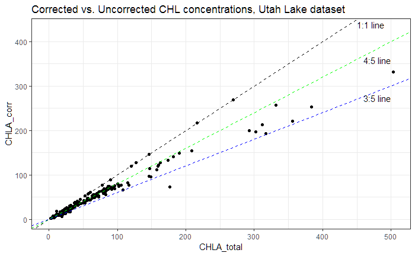

```r
UTLK_0 %>%
    filter(CharacteristicName %in% param & CharacteristicName != "Pheophytin a") %>%
    mutate(
      PARAM01 = case_when(
        CharacteristicName %in% c("Chlorophyll a, corrected for pheophytin",
                                  "Chlorophyll a, free of pheophytin") ~ "CHLA_corr",
        CharacteristicName %in% c("Chlorophyll a",
                                  "Chlorophyll a, uncorrected for pheophytin") ~ "CHLA_total",
        TRUE ~ as.character(NA))) %>%
    select(ActivityIdentifier, PARAM01,
           ResultMeasureValue) %>% arrange(ActivityIdentifier, PARAM01) %>%
    complete(., ActivityIdentifier, PARAM01) %>%
    reshape2::dcast(.,
                    ActivityIdentifier ~ PARAM01, value.var = "ResultMeasureValue",
                    mean, na.rm=T) %>%
    filter(!is.na(CHLA_corr) & !is.na(CHLA_total)) %>%

    ggplot(.,
           aes(x = CHLA_total, y = CHLA_corr)) + theme_bw() +
    geom_point(na.rm=T) +
    geom_abline(slope=1, intercept=0, lty=2, col="black") +
    geom_abline(slope=0.8, intercept=0, lty=2, col="green") +
    geom_abline(slope=0.6, intercept=0, lty=2, col="blue") +
    scale_x_continuous(limits=c(0, NA)) +
    scale_y_continuous(limits=c(0, NA)) +
    annotate("text", x=460, y=265, hjust=0, vjust=0, label="3:5 line") +
    annotate("text", x=460, y=350, hjust=0, vjust=0, label="4:5 line") +
    annotate("text", x=450, y=430, hjust=0, vjust=0, label="1:1 line") +
    ggtitle("Corrected vs. Uncorrected CHL concentrations, Utah Lake dataset")
```

[output not shown]

[output cut: 150 more lines]

### End

**Start work date ::** 190702  
**Last work date ::** 190702  
**Current work / review date ::** 190702

eof